# Cross Validation

# Dotplot

This is a sorted plot of how often each study is selected. We would expect a signal-finding algorithm to be selected more often.

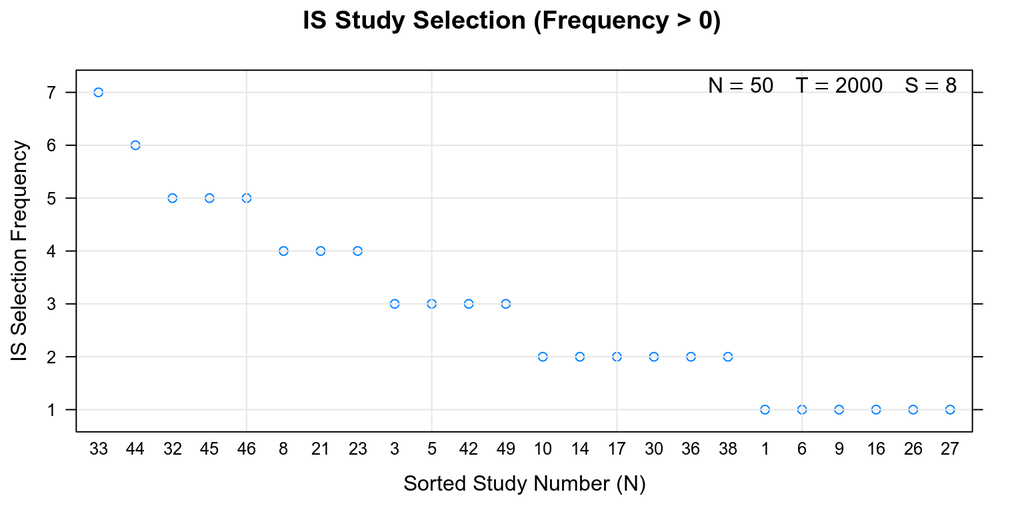

# Pairs

This shows how well in sample selection does out of sample. We would like to see some sort of relationship between them.

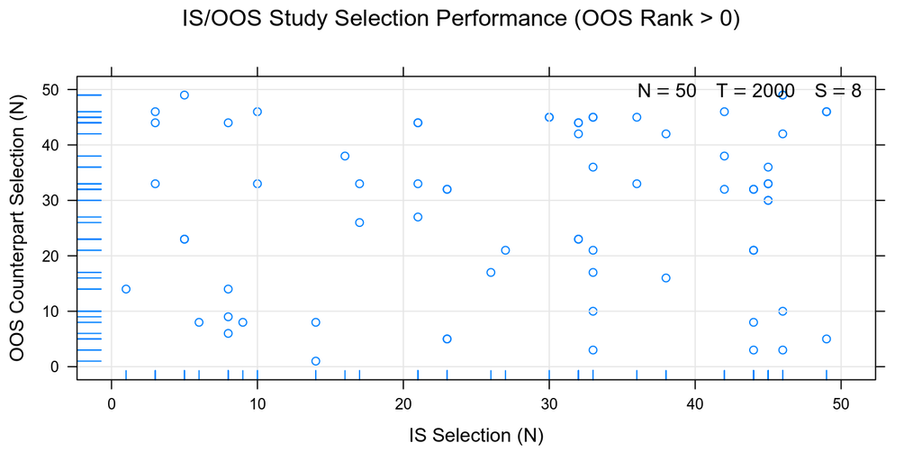

# Ranks

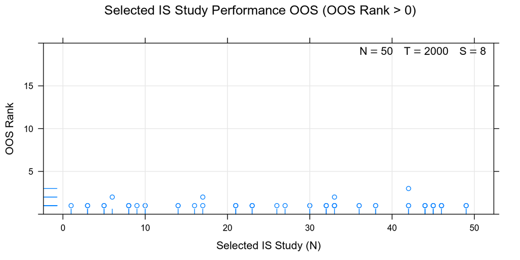